# two_step_approach.R

jfieberg

2023-03-07

## Habitat selection of otters

Coded example for an SSF analysis Authors: S. Muff, J. Signer, J. Fieberg The otter data are taken from Weinberger et al (2016). Flexible habitat selection paves the way for a recovery of otter populations in the European Alps, Biological Conservation 199, p. 88-95, https://doi.org/10.1016/j.biocon.2016.04.017

```r
# Load libraries and read in data
```

```r
library(survival)
library(tidyverse)
library(glmmTMB)
library(broom)
library(tictoc)

dat <-  read.csv("https://raw.githubusercontent.com/jfieberg/ISEC_HSF_Workshop/main/Data/d_otter.csv")
```

## Part 1: Data wrangling

NAT1, REST1 and STAU1 are the three factor levels of the factor variable “habitat type”, encoded as dummy variables, where

- NAT1: natural habitat (reference category)
- REST1: residual water
- STAU1: a reservoir Further, the two continuous variables in the model are:
- Sohlbrei: the river width
- Breaks_Dis: step length Finally, `Loc` is the binary response variable that indicates if a habitat point was used (1) or available (0). Some data manipulation: Scale and center the two continuous variables river width (Sohlenbrei) and step length (Breaks_Dis)

```r
dat$Sohlenbrei <- scale(dat$Sohlenbrei)
dat$Breaks_Dis <- scale(dat$Breaks_Dis)
```

Add numerical variable for animals:

```r
dat$ANIMAL_ID <- as.numeric(as.factor(dat$NA_ANIMAL))
```

Stratum ID is given as “NA_ID” in the data; It is easier to have sequential enumeration, so let’s generate a new stratum-ID variable str_ID:

```r
d.map <- data.frame(NA_ID=unique(dat$NA_ID),str_ID=1:length(unique(dat$NA_ID)))
dat$str_ID <- d.map[match(dat$NA_ID,d.map$NA_ID),"str_ID"]
dat <- dat[order(dat$str_ID),]
```

Getting to know the data better:

```r
str(dat)
```

```
## 'data.frame':    41670 obs. of  10 variables:
##  $ NA_ANIMAL : chr  "Dan" "Dan" "Dan" "Dan" ...
##  $ NA_ID     : int  11624 11624 11624 11624 11624 11624 11624 11624 11624 11624 ...
##  $ Loc       : int  0 0 0 0 0 0 0 0 0 1 ...
##  $ Sohlenbrei: num [1:41670, 1] -0.569 -0.569 -0.569 -0.569 -0.569 ...
##  $ NAT1      : int  0 0 0 0 0 0 0 0 0 0 ...
##  $ REST1     : int  1 1 1 1 1 1 1 1 1 1 ...
##  $ STAU1     : int  0 0 0 0 0 0 0 0 0 0 ...
##  $ Breaks_Dis: num [1:41670, 1] -0.665 -0.581 -0.531 -0.385 -0.89 ...
##  $ ANIMAL_ID : num  4 4 4 4 4 4 4 4 4 4 ...
##  $ str_ID    : int  1 1 1 1 1 1 1 1 1 1 ...
```

## Part 4: Two-step approach

We will use two approaches here: 1. Using a for loop. 2. Using list columns. For loops are more intuitive, but can become a bit tedious, especially when more than two grouping factors should be considered. The basic idea, however, is always the same. We want to fit for each animal separately the same model (`Loc ~ STAU1 + REST1 + Sohlenbrei + Breaks_Dis + strata(str_ID)`) and then extract coefficients.

```r
# For loops are more intuitive, but can become a bit tedious, especially when
# more than two grouping factors should be considered.


# The basic idea, however, is always the same. We want to fit for each animal
# separatly the same model (`Loc ~ STAU1 + REST1 + Sohlenbrei +  Breaks_Dis +
# strata(str_ID)`) and then extract coefficients.
```

### Using a `for`-loop —-

We first want to know the name of all animals that are in the data set.

```r
unique(dat$NA_ANIMAL)
```

```
## [1] "Dan"       "Alena"     "Johanna"   "Fee"       "Hans"      "Baukje"
## [7] "Ivo"       "Cleopatra" "Gessa"
```

```r
# Lets fit the model to one animal (e.g., Alena)
head(dat)
```

```
##   NA_ANIMAL NA_ID Loc Sohlenbrei NAT1 REST1 STAU1 Breaks_Dis ANIMAL_ID str_ID
## 1       Dan 11624   0 -0.5694449    0     1     0 -0.6647002         4      1
## 2       Dan 11624   0 -0.5694449    0     1     0 -0.5814251         4      1
## 3       Dan 11624   0 -0.5694449    0     1     0 -0.5307450         4      1
## 4       Dan 11624   0 -0.5694449    0     1     0 -0.3845509         4      1
## 5       Dan 11624   0 -0.5694449    0     1     0 -0.8895453         4      1
## 6       Dan 11624   0 -0.5694449    0     1     0  0.3659132         4      1
```

```r
m1 <- clogit(Loc ~ STAU1 + REST1 + Sohlenbrei +  Breaks_Dis + strata(str_ID),
       data = dat[dat$NA_ANIMAL == "Alena", ])
```

```r
# package `broom`.
tidy(m1)
```

```
## # A tibble: 4 × 5
##   term       estimate std.error statistic  p.value
##   <chr>         <dbl>     <dbl>     <dbl>    <dbl>
## 1 STAU1       -0.434     0.375      -1.16 0.247
## 2 REST1       -0.888     0.331      -2.68 0.00733
## 3 Sohlenbrei  -0.394     0.305      -1.29 0.197
## 4 Breaks_Dis   0.0990    0.0300      3.30 0.000970
```

But we are interested in *all* animals, so we need to iterate over all animals

```r
# and make sure we save the results.
res <- list()
for (i in unique(dat$NA_ANIMAL)) {
  m <- clogit(Loc ~ STAU1 + REST1 + Sohlenbrei +  Breaks_Dis + strata(str_ID),
              data = dat[dat$NA_ANIMAL == i, ])
  res[[i]] <- tidy(m)
}

res
```

```
## $Dan
## # A tibble: 4 × 5
##   term       estimate std.error statistic p.value
##   <chr>         <dbl>     <dbl>     <dbl>   <dbl>
## 1 STAU1        0.0596    0.250      0.238  0.812
## 2 REST1       -0.326     0.187     -1.74   0.0814
## 3 Sohlenbrei  -0.350     0.278     -1.26   0.208
## 4 Breaks_Dis  -0.0882    0.0699    -1.26   0.207
##
## $Alena
## # A tibble: 4 × 5
##   term       estimate std.error statistic  p.value
##   <chr>         <dbl>     <dbl>     <dbl>    <dbl>
## 1 STAU1       -0.434     0.375      -1.16 0.247
## 2 REST1       -0.888     0.331      -2.68 0.00733
## 3 Sohlenbrei  -0.394     0.305      -1.29 0.197
## 4 Breaks_Dis   0.0990    0.0300      3.30 0.000970
##
## $Johanna
## # A tibble: 4 × 5
##   term       estimate std.error statistic   p.value
##   <chr>         <dbl>     <dbl>     <dbl>     <dbl>
## 1 STAU1        1.79      0.497      3.60  0.000318
## 2 REST1        1.50      0.505      2.97  0.00299
## 3 Sohlenbrei  -0.0420    0.0964    -0.436 0.663
## 4 Breaks_Dis   0.258     0.0629     4.10  0.0000407
##
## $Fee
## # A tibble: 4 × 5
##   term       estimate std.error statistic p.value
##   <chr>         <dbl>     <dbl>     <dbl>   <dbl>
## 1 STAU1       -0.331     0.539     -0.614 0.539
## 2 REST1        0.228     0.545      0.418 0.676
## 3 Sohlenbrei  -0.0450    0.0670    -0.672 0.502
## 4 Breaks_Dis  -0.187     0.0642    -2.92  0.00348
##
## $Hans
## # A tibble: 4 × 5
##   term       estimate std.error statistic p.value
##   <chr>         <dbl>     <dbl>     <dbl>   <dbl>
```

[output cut: 25 more lines]

```
##   term       estimate std.error statistic  p.value
##   <chr>         <dbl>     <dbl>     <dbl>    <dbl>
## 1 STAU1         0.586     0.457     1.28  1.99e- 1
## 2 REST1        -0.130     0.375    -0.346 7.30e- 1
## 3 Sohlenbrei   -0.468     0.925    -0.506 6.13e- 1
## 4 Breaks_Dis   -1.20      0.122    -9.78  1.39e-22
##
## $Gessa
## # A tibble: 4 × 5
##   term       estimate std.error statistic p.value
##   <chr>         <dbl>     <dbl>     <dbl>   <dbl>
## 1 STAU1        -0.412    0.133     -3.09  0.00203
## 2 REST1        -0.113    0.710     -0.159 0.873
## 3 Sohlenbrei    0.338    0.253      1.34  0.181
## 4 Breaks_Dis   -0.104    0.0605    -1.72  0.0853
```

Next, we want to compare the coefficients for different animals. We have to bind the individual results together first.

```r
bind_rows(res)
```

```
## # A tibble: 36 × 5
##    term       estimate std.error statistic  p.value
##    <chr>         <dbl>     <dbl>     <dbl>    <dbl>
##  1 STAU1        0.0596    0.250      0.238 0.812
##  2 REST1       -0.326     0.187     -1.74  0.0814
##  3 Sohlenbrei  -0.350     0.278     -1.26  0.208
##  4 Breaks_Dis  -0.0882    0.0699    -1.26  0.207
##  5 STAU1       -0.434     0.375     -1.16  0.247
##  6 REST1       -0.888     0.331     -2.68  0.00733
##  7 Sohlenbrei  -0.394     0.305     -1.29  0.197
##  8 Breaks_Dis   0.0990    0.0300     3.30  0.000970
##  9 STAU1        1.79      0.497      3.60  0.000318
## 10 REST1        1.50      0.505      2.97  0.00299
## # … with 26 more rows
```

We might want to know the name of the animal too.

```r
coefs0 <- bind_rows(res, .id = "name")
```

We will explore later, how to do summarize these results. But first, we will explore the use of list columns to do the same. ### Using list columns

```r
dat.n <- dat %>% nest(data = -c(NA_ANIMAL))
dat.n$NA_ANIMAL[4]
```

```
## [1] "Fee"
```

```r
dat.n$data[[4]]
```

```
## # A tibble: 3,840 × 9
##    NA_ID   Loc Sohlenbrei[,1]  NAT1 REST1 STAU1 Breaks_Dis[,1] ANIMAL_ID str_ID
##    <int> <int>          <dbl> <int> <int> <int>          <dbl>     <dbl>  <int>
##  1 33117     0         -0.483     1     0     0        -0.655          5   1006
##  2 33117     0         -0.656     1     0     0        -0.551          5   1006
##  3 33117     0         -0.656     1     0     0        -0.519          5   1006
##  4 33117     0         -0.743     1     0     0         4.40           5   1006
##  5 33117     0         -0.656     1     0     0        -0.396          5   1006
##  6 33117     0         -0.656     1     0     0         0.0278         5   1006
##  7 33117     0         -0.656     1     0     0        -0.852          5   1006
##  8 33117     0         -0.656     1     0     0        -0.728          5   1006
##  9 33117     0         -0.483     1     0     0        -0.699          5   1006
## 10 33117     1         -0.483     0     1     0        -0.942          5   1006
## # … with 3,830 more rows
```

We could add as many grouping variables as we want to `-c(NA_ANIMAL)` to make the model more complex. Each element of the list `data` is a `data.frame` with the data for a given animal.

```r
dat.n$data[[4]]
```

```
## # A tibble: 3,840 × 9
##    NA_ID   Loc Sohlenbrei[,1]  NAT1 REST1 STAU1 Breaks_Dis[,1] ANIMAL_ID str_ID
##    <int> <int>          <dbl> <int> <int> <int>          <dbl>     <dbl>  <int>
##  1 33117     0         -0.483     1     0     0        -0.655          5   1006
##  2 33117     0         -0.656     1     0     0        -0.551          5   1006
##  3 33117     0         -0.656     1     0     0        -0.519          5   1006
##  4 33117     0         -0.743     1     0     0         4.40           5   1006
##  5 33117     0         -0.656     1     0     0        -0.396          5   1006
##  6 33117     0         -0.656     1     0     0         0.0278         5   1006
##  7 33117     0         -0.656     1     0     0        -0.852          5   1006
##  8 33117     0         -0.656     1     0     0        -0.728          5   1006
##  9 33117     0         -0.483     1     0     0        -0.699          5   1006
## 10 33117     1         -0.483     0     1     0        -0.942          5   1006
## # … with 3,830 more rows
```

This makes it easy to fit an individual model for each animal

```r
dat.n <- dat.n %>%
  mutate(
    ssf = map(data, ~
                clogit(Loc ~ STAU1 + REST1 + Sohlenbrei +  Breaks_Dis + strata(str_ID),
                       data = .x) %>% tidy()))

dat.n <- dat.n %>%
  mutate(
    ssf = lapply(data, function(.x)
                clogit(Loc ~ STAU1 + REST1 + Sohlenbrei +  Breaks_Dis + strata(str_ID),
                       data = .x) %>% tidy()))
dat.n
```

```
## # A tibble: 9 × 3
##   NA_ANIMAL data                  ssf
##   <chr>     <list>                <list>
## 1 Dan       <tibble [2,760 × 9]>  <tibble [4 × 5]>
## 2 Alena     <tibble [11,770 × 9]> <tibble [4 × 5]>
## 3 Johanna   <tibble [2,280 × 9]>  <tibble [4 × 5]>
## 4 Fee       <tibble [3,840 × 9]>  <tibble [4 × 5]>
## 5 Hans      <tibble [4,200 × 9]>  <tibble [4 × 5]>
## 6 Baukje    <tibble [6,260 × 9]>  <tibble [4 × 5]>
## 7 Ivo       <tibble [3,490 × 9]>  <tibble [4 × 5]>
## 8 Cleopatra <tibble [3,200 × 9]>  <tibble [4 × 5]>
## 9 Gessa     <tibble [3,870 × 9]>  <tibble [4 × 5]>
```

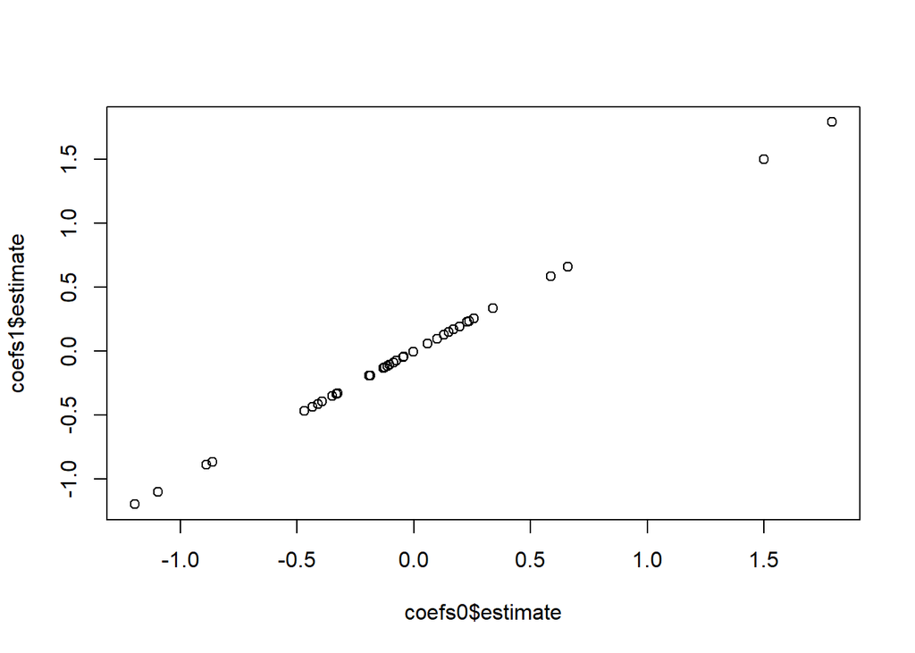

```r
coefs1 <- dat.n %>% select(NA_ANIMAL, ssf) %>% unnest(cols = ssf)


# Ensure the two approaches lead to the same result (which they do).
plot(coefs0$estimate, coefs1$estimate)
```

## Working with the results

We could now work with the coefficients and for example plot males vs. females or some other individual property. Here we will only calculate the mean and a CI for the mean. We use a bootstrap for the mean

```r
coefs1
```

```
## # A tibble: 36 × 6
##    NA_ANIMAL term       estimate std.error statistic  p.value
##    <chr>     <chr>         <dbl>     <dbl>     <dbl>    <dbl>
##  1 Dan       STAU1        0.0596    0.250      0.238 0.812
##  2 Dan       REST1       -0.326     0.187     -1.74  0.0814
##  3 Dan       Sohlenbrei  -0.350     0.278     -1.26  0.208
##  4 Dan       Breaks_Dis  -0.0882    0.0699    -1.26  0.207
##  5 Alena     STAU1       -0.434     0.375     -1.16  0.247
##  6 Alena     REST1       -0.888     0.331     -2.68  0.00733
##  7 Alena     Sohlenbrei  -0.394     0.305     -1.29  0.197
##  8 Alena     Breaks_Dis   0.0990    0.0300     3.30  0.000970
##  9 Johanna   STAU1        1.79      0.497      3.60  0.000318
## 10 Johanna   REST1        1.50      0.505      2.97  0.00299
## # … with 26 more rows
```

```r
pop <- coefs1 %>% nest(dat = -term) %>%
  mutate(
    mean = map_dbl(dat, ~ mean(.x$estimate)),
    boot = map(dat, ~ replicate(1e4, mean(sample(.x$estimate, replace = TRUE)))),
    lci = map_dbl(boot, ~ quantile(.x, probs = 0.025)),
    uci = map_dbl(boot, ~ quantile(.x, probs = 0.975)))
```

We can use this data to create a plot

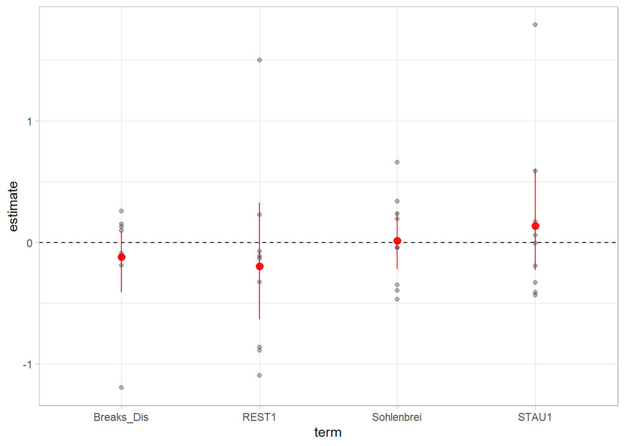

```r
coefs0 %>%
  ggplot(aes(term, estimate)) +
  geom_hline(yintercept = 0, lty = 2) +
  geom_point(alpha = 0.3) +
  geom_pointrange(aes(ymin = lci, ymax = uci, y = mean),
                  data = pop, alpha = 0.9, col = "red") +
  theme_light()
```

### Compare with glmmTMB()

Now let us compare our results to what we got using glmmTMB

```r
tic()
glmm.TMB.random = glmmTMB(Loc ~ -1 + STAU1 + REST1 + Sohlenbrei +
                            Breaks_Dis + (1|str_ID) +
                            (0 + STAU1 | ANIMAL_ID) +
                            (0 + REST1 | ANIMAL_ID) +
                            (0 + Breaks_Dis | ANIMAL_ID) +
                            (0 + Sohlenbrei | ANIMAL_ID),
                          family=poisson, data = dat,
                          map = list(theta = factor(c(NA, 1:4))),
                          start = list(theta = c(log(1e3), 0, 0, 0, 0))
)
toc()
```

```
## 5 sec elapsed
```

```r
summary(glmm.TMB.random)
```

```
##  Family: poisson  ( log )
## Formula:
## Loc ~ -1 + STAU1 + REST1 + Sohlenbrei + Breaks_Dis + (1 | str_ID) +
##     (0 + STAU1 | ANIMAL_ID) + (0 + REST1 | ANIMAL_ID) + (0 +
##     Breaks_Dis | ANIMAL_ID) + (0 + Sohlenbrei | ANIMAL_ID)
## Data: dat
##
##      AIC      BIC   logLik deviance df.resid
##  84864.3  84933.4 -42424.2  84848.3    41662
##
## Random effects:
##
## Conditional model:
##  Groups      Name        Variance  Std.Dev.
##  str_ID      (Intercept) 1.000e+06 1000.0000
##  ANIMAL_ID   STAU1       7.806e-02    0.2794
##  ANIMAL_ID.1 REST1       1.546e-01    0.3932
##  ANIMAL_ID.2 Breaks_Dis  1.464e-01    0.3827
##  ANIMAL_ID.3 Sohlenbrei  6.422e-02    0.2534
## Number of obs: 41670, groups:  str_ID, 4167; ANIMAL_ID, 9
##
## Conditional model:
##            Estimate Std. Error z value Pr(>|z|)
## STAU1      -0.01165    0.13761  -0.085   0.9325
## REST1      -0.32815    0.18294  -1.794   0.0728 .
## Sohlenbrei  0.12146    0.11051   1.099   0.2717
## Breaks_Dis -0.11405    0.12941  -0.881   0.3782
## ---
## Signif. codes:  0 '***' 0.001 '**' 0.01 '*' 0.05 '.' 0.1 ' ' 1
```

Combine results and plot

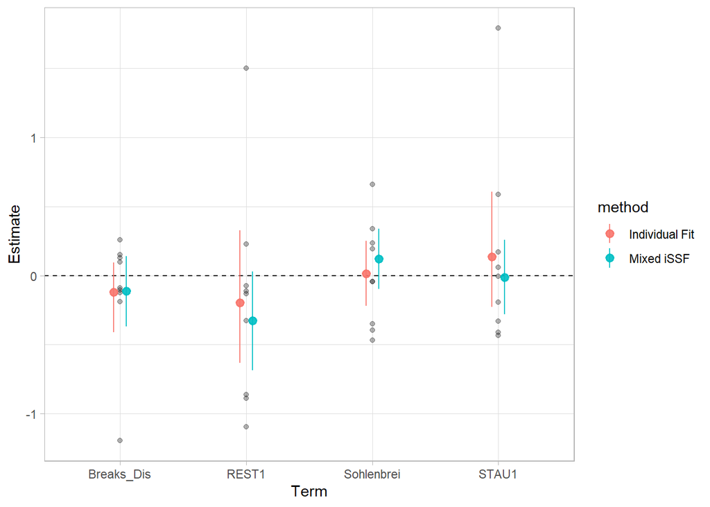

```r
pop2 <- pop %>% select(term, mean, lci, uci) %>%
  rename(Estimate = mean, Term = term)
mixediSSF <- confint(glmm.TMB.random)
mixedcoef <- data.frame(Term = pop2$Term,
                        Estimate = mixediSSF[1:4, 3],
                        lci = mixediSSF[1:4, 1],
                        uci = mixediSSF[1:4, 2])
pop2 <- rbind(pop2, mixedcoef)
pop2$method<-rep(c("Individual Fit", "Mixed iSSF"), each=4)

coefs0 <- coefs0 %>% rename(Term = term, Estimate=estimate)
ggplot(coefs0, aes(Term, Estimate)) +
  geom_point(alpha = 0.3) +
  geom_hline(yintercept = 0, lty = 2) +
  geom_pointrange(aes(ymin = lci, ymax = uci, y = Estimate, col = method),
                   data=pop2, alpha = 0.9, position = position_dodge2(width=0.2)) +
  theme_light()
```